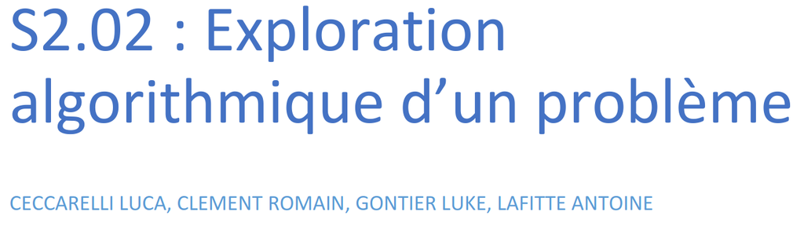

# Table des Matières :

- Partie 1 : PageRank - Version itérative
- Partie 2 : PageRank - Analyse
  - Question A
  - Question B
  - Question C
  - Question D
- Partie 3 : PageRank - Calcul direct des scores
  - Question A
  - Question B
  - Question C
  - Question D
- Partie 4 : Comparaison & analyse
  - Question A
  - Question B
  - Question C

# Partie 1 : PageRank - Version itérative

```python
import numpy as np

def norme(X):
    ### Renvoie la norme du vecteur X passé en paramètre (list ou np.array)
    somme_des_carres = 0
    for valeur in X:
        somme_des_carres += valeur**2
    return np.sqrt(somme_des_carres)

def transition(M, lamb):
    ### Renvoie la matrice de transition P, à partir de la matrice M et du facteur d'amortissement lambda
    ordre = len(M)
    P = np.zeros((ordre, ordre))
    for colonne in range(ordre):
        somme_colonne = sum(M[:,colonne])      # Calcul de la somme des coefficients de la colonne
        if somme_colonne != 0:
            for ligne in range(ordre):
                P[ligne][colonne] = round(lamb * (M[ligne][colonne]/somme_colonne) + (1 - lamb) * (1/ordre), 14)
        else:
            for ligne in range(ordre):
                P[ligne][colonne] = round(1/ordre, 14)
    return P

def page_rank(M, lamb, eps):
    ### Algorithme de Page Rank
    ordre = len(M)
    P = transition(M.transpose(), lamb)
    Rl = np.array([1/ordre] * ordre)    # Représente R(l)
    Rl1 = P @ Rl                        # Représente R(l+1)
    l = 0
    while norme(Rl - Rl1) >= eps:
        Rl = Rl1
        Rl1 = P @ Rl1
        l += 1
    return l, Rl1
```

```python
M = np.array([[0,1,1,1,1,1,0,0,0,0,0,0,0,1,1,1,0,0,0,1,1,0,0,0,0,1],
              [0,0,1,1,1,1,1,1,1,1,1,1,1,1,1,1,1,1,1,1,1,1,1,1,1,1],
              [0,1,1,0,0,0,0,0,0,0,0,0,0,0,0,0,0,0,0,0,0,0,0,0,0,0],
              [0,1,0,1,0,0,0,0,0,0,0,0,0,0,0,0,0,0,0,0,0,0,0,0,0,0],
              [0,1,0,0,0,0,0,0,0,0,0,0,0,0,0,0,0,0,0,0,0,0,0,0,0,0],
              [0,1,0,0,0,0,0,0,0,0,0,0,0,0,0,0,0,0,0,0,0,0,0,0,0,0],
              [0,1,1,1,0,0,0,0,0,0,0,0,1,0,0,1,0,1,0,1,1,1,1,1,0,1],
              [0,1,0,0,1,1,0,0,0,0,0,0,0,0,0,1,0,0,0,0,0,0,0,0,0,0],
              [0,1,0,0,0,0,0,0,0,0,0,0,0,0,0,0,1,0,0,0,0,0,0,0,0,0],
              [0,1,0,0,0,0,0,0,0,0,0,0,0,0,0,1,0,0,0,0,0,0,0,0,0,0],
              [0,1,0,0,0,0,0,0,0,0,0,0,0,0,0,1,0,0,0,0,0,0,0,0,0,0],
              [0,1,0,0,0,0,0,0,0,0,0,0,0,0,0,0,0,0,1,0,0,0,0,0,1,0],
              [0,1,0,0,0,0,0,0,0,0,0,0,0,0,0,1,0,0,0,0,0,0,0,0,0,0],
              [0,1,0,0,0,0,0,0,0,0,0,0,0,0,1,1,0,0,0,0,0,0,0,0,0,0],
              [0,1,0,0,0,0,0,0,0,0,0,0,0,1,0,1,0,0,0,0,0,0,0,0,0,0],
              [0,1,0,0,0,0,0,0,0,0,0,0,0,0,0,1,0,0,0,0,0,0,0,0,0,0],
              [0,1,0,0,0,0,0,0,1,0,0,0,0,0,0,0,0,0,0,0,0,0,0,0,0,0],
              [0,1,0,0,0,0,0,0,0,0,0,0,0,0,0,0,0,0,0,0,0,0,0,0,0,0],
              [0,1,0,0,0,0,1,0,0,0,0,1,0,0,0,1,0,0,0,0,0,0,0,0,0,0],
              [0,1,0,0,0,0,0,0,0,0,0,0,0,0,0,1,0,0,0,0,1,0,0,1,0,1],
              [0,1,0,0,0,0,1,0,0,0,0,0,0,0,0,0,0,0,0,1,0,0,0,0,0,0],
              [0,1,0,0,0,0,0,0,0,0,0,0,0,0,0,0,0,0,0,0,0,0,0,0,0,0],
              [0,1,0,0,0,0,1,0,0,0,0,0,0,0,0,1,0,0,0,0,0,0,0,0,0,0],
              [0,1,0,0,0,0,0,0,0,0,0,0,0,0,0,0,0,0,0,0,0,0,0,0,0,0],
              [0,1,0,0,0,0,1,0,0,0,0,0,0,0,0,0,0,0,1,0,0,0,0,0,0,0],
              [0,1,1,1,0,0,1,0,0,0,0,0,0,0,0,1,0,0,0,0,0,0,0,0,0,0]])
```

# Partie 2 : Pagerank - Analyse

## Question A

On observe que plus on augmente la précision de l'algorithme plus le score des pages devient précis :

Pour la page à la position 25 :

- 0.02420339 avec ε = 10<sup>-3</sup>
- 0.02422593 avec ε = 10<sup>-6</sup>
- 0.0242259 avec ε = 10<sup>-9</sup>

Pour la page à la position 4 :

- 0.01992733 avec ε = 10<sup>-3</sup>
- 0.01994111 avec ε = 10<sup>-6</sup>
- 0.01994109 avec ε = 10<sup>-9</sup>

À travers ces exemples, on peut remarquer que les valeurs ne changent pas drastiquement, en effet, plus on augmente la précision plus les différents scores vont s'approcher entre elles. On remarque donc que le score d'une page converge lorsque ε tend vers 0.

## Question B

L'algorithme Page Rank octroie un meilleur rang à une page en fonction du nombre de liens s'orientant vers elle. Une autorité est une page référencée dans de nombreuses autres. Elle sera donc mieux classée que des hubs qui, eux, renvoient vers beaucoup de pages.

```python
M2 = np.array([[0,1,1,1,1,1,0,0,0,0,1,0,0,1,1,1,0,0,0,1,1,0,0,1,0,1],
               [0,0,1,1,1,1,1,1,1,1,1,1,1,1,1,1,1,1,1,1,1,1,1,1,1,1],
               [0,1,1,0,1,0,0,0,0,0,1,0,0,0,0,0,0,0,0,0,0,0,0,1,0,0],
               [0,1,0,1,1,0,0,0,0,0,1,0,0,0,0,0,0,0,0,0,0,0,0,1,0,0],
               [0,1,0,0,1,0,0,0,0,0,1,0,0,0,0,0,0,0,0,0,0,0,0,1,0,0],
               [0,1,0,0,1,0,0,0,0,0,1,0,0,0,0,0,0,0,0,0,0,0,0,1,0,0],
               [0,1,1,1,1,0,0,0,0,0,1,0,1,0,0,1,0,1,0,1,1,1,1,1,0,1],
               [1,1,1,1,1,1,1,1,1,1,1,1,1,1,1,1,1,1,1,1,1,1,1,1,1,1],
               [0,1,0,0,1,0,0,0,0,0,1,0,0,0,0,0,1,0,0,0,0,0,0,1,0,0],
               [0,1,0,0,1,0,0,0,0,0,1,0,0,0,0,1,0,0,0,0,0,0,0,1,0,0],
               [0,1,0,0,1,0,0,0,0,0,1,0,0,0,0,1,0,0,0,0,0,0,0,1,0,0],
               [1,1,1,1,1,1,1,1,1,1,1,1,1,1,1,1,1,1,1,1,1,1,1,1,1,1],
               [0,1,0,0,1,0,0,0,0,0,1,0,0,0,0,1,0,0,0,0,0,0,0,1,0,0],
               [0,1,0,0,1,0,0,0,0,0,1,0,0,0,1,1,0,0,0,0,0,0,0,1,0,0],
               [0,1,0,0,1,0,0,0,0,0,1,0,0,1,0,1,0,0,0,0,0,0,0,1,0,0],
               [0,1,0,0,1,0,0,0,0,0,1,0,0,0,0,1,0,0,0,0,0,0,0,1,0,0],
               [0,1,0,0,1,0,0,0,1,0,1,0,0,0,0,0,0,0,0,0,0,0,0,1,0,0],
               [1,1,1,1,1,1,1,1,1,1,1,1,1,1,1,1,1,1,1,1,1,1,1,1,1,1],
               [0,1,0,0,1,0,1,0,0,0,1,1,0,0,0,1,0,0,0,0,0,0,0,1,0,0],
               [1,1,1,1,1,1,1,1,1,1,1,1,1,1,1,1,1,1,1,1,1,1,1,1,1,1],
               [0,1,0,0,1,0,1,0,0,0,1,0,0,0,0,0,0,0,0,1,0,0,0,1,0,0],
               [0,1,0,0,1,0,0,0,0,0,1,0,0,0,0,0,0,0,0,0,0,0,0,1,0,0],
               [0,1,0,0,1,0,1,0,0,0,1,0,0,0,0,1,0,0,0,0,0,0,0,1,0,0],
               [0,1,0,0,1,0,0,0,0,0,1,0,0,0,0,0,0,0,0,0,0,0,0,1,0,0],
               [0,1,0,0,1,0,1,0,0,0,1,0,0,0,0,0,0,0,1,0,0,0,0,1,0,0],
               [0,1,1,1,1,0,1,0,0,0,1,0,0,0,0,1,0,0,0,0,0,0,0,1,0,0]])
# le site 16 devient un hub
# le site 9 devient une autorité
```

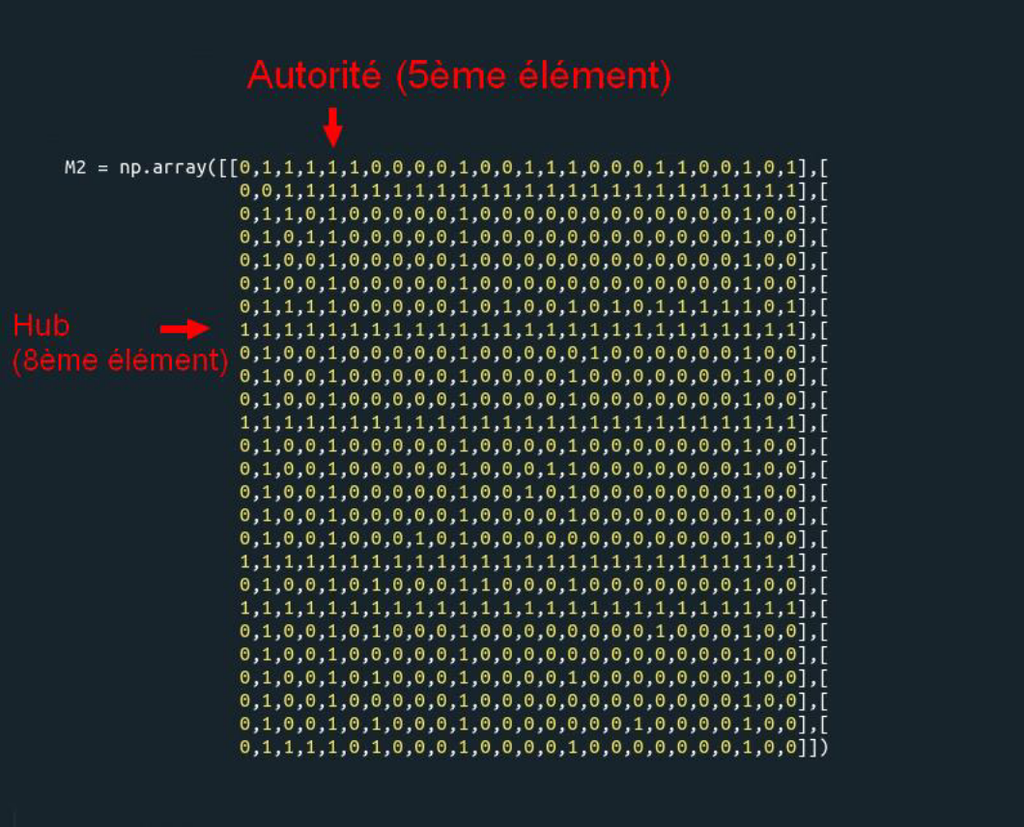

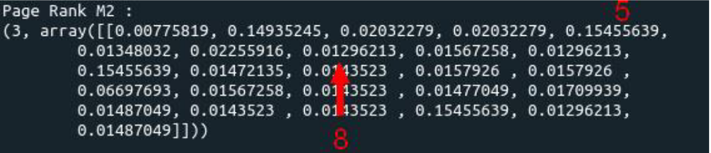

La cinquième page est une autorité et la huitième un hub. On remarque que le score de l’autorité (5ème valeur) est plus de dix fois supérieure à celui du hub (8ème valeur).

## Question C

Pour accroître le rang de certaines pages, il faut d'abord se rappeler qu'il y a trois conditions dans l'augmention du score avec Page Rank :

- Une page gagne des points si elle est référencée dans une autre.
- Une page au score plus élevé qu'une autre donnera plus de points aux pages vers qui elle redirige.
- Il y a une troisième condition : une page donnera plus ou moins de points à ses successeurs dépendament de leur nombre. C'est à dire que plus un sommet a de successeurs, moins il va donner de points à chacun.

## Question D

Lorsque l'on approche lambda de 0, on remarque que le score des pages se rapproche de plus en plus de la valeur 0.03846154 qui vaut environ 1/26. On peut alors dire que lorsque lambda vaut 0, tous les scores sont égaux à 1/|S|, ceci |S| fois, ce qui vaut égalment la matrice Rl au départ de l'algorithme.

# Partie 3 : PageRank - Calcul direct des scores

## Question A

Pour vérifier que R<sub>l</sub> soit approximativement le vecteur propre de la matrice P associé à la valeur propre 1, nous avons utilisé l'équation AX = λX avec A = P, X = R<sub>l</sub> et λ = 1. (On note que P admet bien 1 comme valeur propre car P est une matrice stochastique.) Autrement dit, nous avons vérifé à l’aide de Python que AX - λX ≈ 0 :

```python
P = transition(M.transpose(), 0.85)
Rl = page_rank(M, 0.85, 10**-9)[1]
print(norme((P @ Rl) - (1 * Rl)))
```

```
2.8061578455284586e-10
```

La valeur est très proche de 0, donc on peut en déduire que la proposition de la question est vraie.

## Question B

Algorithme : Calcul de Page Rank à l’aide du vecteur propre

Donnée : M une matrice carrée stochastique  
ordre <- taille de M  
n <- 2<sup>32</sup>  
X<sub>0</sub> = (1/ordre, ..., 1/ordre) de taille ordre  
Renvoyer M<sup>n</sup> × X<sub>0</sub>

Pour des raisons d'optimisation lors de l'implémentation de l'algorithme en Python, on choisit n = 2<sup>k</sup> ce qui permet d'avoir une complexité optimale égale à k lors du calcul de M<sup>n</sup>.

## Question C

```python
def puissance_dichotomique(M, n):
    ### Algorithme récursif qui permet de calculer la matrice M élevée à la puissance n
    # On note que l'algorithme est très efficace lorsque n = 2^k
    # il y a k appels à la fonction donc k mulitplications
    if (n == 1):
        return M
    elif (n%2 == 0):
        M2 = puissance_dichotomique(M, n/2)
        return M2 @ M2
    else:
        M2 = puissance_dichotomique(M, (n-1)/2)
        return M @ M2 @ M2

def calcul_vecteur_propre(M):
    ### Renvoie le vecteur propre associé à 1 de la matrice stochastique M
    # Algorithme déduit de la suite définie par X(n+1) = A * X(n)
    # donc X(n) = A**n * X(0)
    ordre = len(M)
    n = 2**32
    M_puissance_n = puissance_dichotomique(M, n)
    X0 = np.array([1/ordre] * ordre)
    return M_puissance_n @ X0
```

## Question D

```python
matrice_youtube = np.array([[0,1,1,1,1,1,1,1,1,1,1,1,1,0,1,1,1,1,1,1,1,1,1,1,1,1,1,1,1,0,0],
                            [0,1,1,1,0,1,0,0,1,1,0,0,1,0,0,0,0,0,1,1,1,0,0,0,0,0,0,0,1,0,0],
                            [0,1,1,0,1,0,1,1,0,0,1,1,1,0,1,1,1,1,1,1,1,1,1,1,1,1,1,1,1,0,0],
                            [0,1,0,0,0,0,0,0,0,0,0,0,1,0,0,0,0,0,1,1,1,0,0,0,0,0,0,0,1,0,0],
                            [0,1,1,1,1,0,1,1,0,0,1,1,1,0,1,1,1,1,1,1,1,1,1,1,1,1,1,1,1,0,0],
                            [0,1,0,0,0,0,0,0,0,0,0,0,1,0,0,0,0,0,1,1,1,0,0,0,0,0,0,0,1,0,0],
                            [0,1,1,1,1,0,1,1,0,0,1,1,1,0,1,1,1,1,1,1,1,1,1,1,1,1,1,1,1,0,0],
                            [0,1,1,1,1,0,1,1,0,0,1,1,1,0,1,1,1,1,1,1,1,1,1,1,1,1,1,1,1,0,0],
                            [0,1,1,1,1,1,1,1,0,0,1,1,1,0,1,1,1,1,1,1,1,1,1,1,1,1,1,1,1,0,0],
                            [0,1,0,0,0,0,0,0,1,0,0,0,1,0,0,0,0,0,1,1,1,0,0,0,0,0,0,0,1,0,0],
                            [0,1,1,1,1,0,1,1,0,0,1,1,1,0,1,1,1,1,1,1,1,1,1,1,1,1,1,1,1,0,0],
                            [0,1,0,0,0,0,0,0,0,0,0,0,1,0,0,0,0,0,1,1,1,0,0,0,0,0,0,0,1,0,0],
                            [0,1,0,0,0,0,0,0,0,0,0,0,1,0,0,0,0,0,1,1,1,0,0,0,0,0,0,0,1,0,0],
                            [0,1,0,0,0,0,0,0,0,0,0,0,1,0,0,0,0,0,1,1,1,0,0,0,0,0,0,0,1,0,0],
                            [0,0,1,1,1,0,1,1,0,0,1,1,0,0,1,1,1,1,0,0,0,1,1,1,1,1,1,1,0,0,0],
                            [0,0,1,0,1,0,1,1,0,0,1,1,0,0,1,1,1,1,0,0,0,1,1,1,1,1,1,1,0,0,0],
                            [0,0,1,1,1,0,1,1,0,0,1,1,0,0,1,1,1,1,0,0,0,1,1,1,1,1,1,1,0,0,0],
                            [0,0,1,1,1,0,1,1,0,0,1,1,0,0,1,1,1,1,0,0,0,1,1,1,1,1,1,1,0,0,0],
                            [0,0,1,1,1,0,1,1,0,0,1,1,0,0,1,1,1,1,0,0,0,1,1,1,1,1,1,1,0,0,0],
                            [0,0,1,1,1,0,1,1,0,0,1,1,0,0,1,1,1,1,0,1,0,1,1,1,1,1,1,1,0,0,0],
                            [0,0,1,1,1,0,1,1,0,0,1,1,0,0,1,1,1,1,0,0,0,1,1,1,1,1,1,1,0,0,0],
                            [0,0,1,0,1,0,1,1,0,0,1,1,0,0,1,1,1,1,0,0,0,1,1,1,1,1,1,1,0,0,0],
                            [0,0,1,1,1,0,1,1,0,0,1,1,0,0,1,1,1,1,0,0,0,1,1,1,1,1,1,1,0,0,0],
                            [0,0,1,0,1,0,1,1,0,0,1,1,0,0,1,1,1,1,0,0,0,1,1,1,1,1,1,1,0,0,0],
                            [0,0,1,1,1,0,1,1,0,0,1,1,0,0,1,1,1,1,0,0,0,1,1,1,1,1,1,1,0,0,0],
                            [0,0,1,1,1,0,1,1,0,0,1,1,0,0,1,1,1,1,0,0,0,1,1,1,1,1,1,1,0,0,0],
                            [0,0,1,0,1,0,1,1,0,0,1,1,0,0,1,1,1,1,0,0,0,1,1,1,1,1,1,1,0,0,0],
                            [0,0,1,1,1,0,1,1,0,0,1,1,0,0,1,1,1,1,0,0,0,1,1,1,1,1,1,1,0,0,0],
                            [0,0,0,1,0,0,0,0,0,0,0,0,0,0,0,0,0,0,0,0,0,0,0,0,0,0,0,0,0,0,0],
                            [0,0,0,1,0,0,0,0,0,0,0,0,0,0,0,0,0,0,0,0,0,0,0,0,0,0,0,0,0,0,0],
                            [0,0,0,1,0,0,0,0,0,0,0,0,0,0,0,0,0,0,0,0,0,0,0,0,0,0,0,0,0,0,0]])

matrice_facebook = np.array([[0,1,1,0,1,1,1,0,0,0,1,1,1,1,0,0,1,0,1,1,1,0,1,0,1,1,1,1,0,1,1],
                             [0,0,0,0,0,0,0,0,0,0,0,1,0,0,0,0,0,0,1,0,0,0,0,0,0,1,0,0,0,0,0],
                             [0,1,0,0,0,0,0,0,0,0,0,0,0,0,0,0,0,0,0,0,0,0,0,0,0,0,0,0,0,0,0],
                             [0,1,0,0,1,0,0,0,0,0,0,0,0,0,0,0,1,0,0,0,0,0,0,0,0,0,0,0,0,0,0],
                             [0,1,1,0,1,1,1,0,0,0,1,1,0,1,0,0,1,0,0,1,1,0,0,0,1,1,1,1,0,1,1],
                             [0,1,1,0,1,1,1,0,0,0,1,1,0,1,0,0,1,0,0,1,1,0,0,0,1,1,1,1,0,1,1],
                             [0,1,1,0,1,1,1,0,0,0,1,1,0,1,0,0,1,0,0,1,1,0,0,0,1,1,1,1,0,1,1],
                             [0,1,1,0,1,1,1,0,0,0,1,1,0,1,0,0,1,0,0,1,1,0,0,0,1,1,1,1,0,1,1],
                             [0,1,1,0,1,1,1,0,0,0,1,1,0,1,0,0,1,0,0,1,1,0,0,0,1,1,1,1,0,1,1],
                             [0,1,1,0,1,1,1,0,0,0,1,1,0,1,0,0,1,0,0,1,1,0,0,0,1,1,1,1,0,1,1],
                             [0,1,1,0,1,1,1,0,0,0,1,1,0,1,0,0,1,0,0,1,1,0,0,0,1,1,1,1,0,1,1],
                             [0,1,1,0,1,1,1,0,0,0,1,1,0,1,0,0,1,0,0,1,1,0,0,0,1,1,1,1,0,1,1],
                             [0,1,1,0,1,1,1,0,0,0,1,1,1,1,0,0,1,0,0,1,1,0,0,0,1,1,1,1,0,1,1],
                             [0,1,1,0,1,1,1,0,0,0,1,1,0,1,0,0,1,0,0,1,1,0,0,0,1,1,1,1,0,1,1],
                             [0,1,1,0,1,1,1,0,0,0,1,1,0,1,0,0,1,0,0,1,1,0,0,0,1,1,1,1,0,1,1],
                             [0,1,1,0,1,1,1,0,0,0,1,1,0,1,0,0,1,0,0,1,1,0,0,0,1,1,1,1,0,1,1],
                             [0,1,1,0,1,1,1,0,0,0,1,1,0,1,0,0,1,0,0,1,1,0,0,0,1,1,1,1,0,1,1],
                             [0,1,1,0,1,1,1,0,0,0,1,1,0,1,0,0,1,0,0,1,1,0,0,0,1,1,1,1,0,1,1],
                             [0,1,1,0,1,1,1,0,0,0,1,1,0,1,0,0,1,0,0,1,1,0,0,0,1,1,1,1,0,1,1],
                             [0,1,1,0,1,1,1,0,0,0,1,1,1,1,0,0,1,0,0,1,1,0,0,0,1,1,1,1,0,1,1],
                             [0,1,1,0,1,1,1,0,0,0,1,1,0,1,0,0,1,0,0,1,1,0,0,0,1,1,1,1,0,1,1],
                             [0,1,1,0,1,1,1,0,0,0,1,1,1,1,0,0,1,0,0,1,1,0,0,0,1,1,1,1,0,1,1],
                             [0,1,1,0,1,1,1,0,0,0,1,1,1,1,0,0,1,0,0,1,1,0,0,0,1,1,1,1,0,1,1],
                             [0,1,1,0,1,1,1,0,0,0,1,1,0,1,0,0,1,0,0,1,1,0,0,0,1,1,1,1,0,1,1],
                             [0,1,1,0,1,1,1,0,0,0,1,1,0,1,0,0,1,0,0,1,1,0,0,0,1,1,1,1,0,1,1],
                             [0,1,1,0,1,1,1,0,0,0,1,1,0,1,0,0,1,0,0,1,1,0,0,0,1,1,1,1,0,1,1],
                             [0,0,1,0,0,0,0,0,0,0,0,0,0,0,0,0,0,0,0,0,0,0,0,0,0,0,1,1,0,0,0],
                             [0,0,1,0,0,0,0,0,0,0,0,0,0,0,0,0,0,0,0,0,0,0,0,0,0,0,0,0,0,0,0],
                             [0,0,0,1,0,0,0,0,0,0,0,0,0,0,0,0,0,1,0,0,0,0,0,0,0,0,0,0,0,0,0],
                             [0,0,0,0,1,0,0,0,0,0,0,0,0,0,0,0,0,0,0,1,0,0,0,0,0,0,0,0,0,1,1],
                             [0,0,0,0,1,0,0,0,0,0,0,0,0,0,0,0,0,0,0,0,1,0,0,0,0,0,0,0,0,1,1]])

matrice_github = np.array([[0,1,1,1,1,1,1,1,1,1,1,1,1,1,1,1,1,1,1,1,1,1,0,1,1,1,1,1,1,1,1],
                           [0,1,0,1,1,1,1,1,1,1,1,1,1,1,1,1,0,0,0,0,1,0,0,1,1,1,0,0,1,0,0],
                           [0,1,0,0,0,0,0,0,0,0,0,0,0,0,0,0,0,0,0,0,0,0,0,0,0,0,0,0,0,0,0],
                           [0,1,0,1,1,1,1,1,1,1,1,1,1,1,1,1,1,1,1,1,1,1,0,1,1,1,0,1,1,1,0],
                           [0,1,0,1,1,1,1,1,1,1,1,1,1,1,1,1,1,1,1,1,1,1,0,1,1,1,0,1,1,1,0],
                           [0,1,0,1,1,1,1,1,1,1,1,1,1,1,1,1,1,1,1,1,1,1,0,1,1,1,0,1,1,1,0],
                           [0,1,0,1,1,1,1,1,1,1,1,1,1,1,1,1,1,1,1,1,1,1,0,1,1,1,0,1,1,1,0],
                           [0,1,0,1,1,1,1,1,1,1,1,1,1,1,1,1,1,1,1,1,1,1,0,1,1,1,0,1,1,1,0],
                           [0,1,0,1,1,1,1,1,1,1,1,1,1,1,1,1,1,1,1,1,1,1,0,1,1,1,0,1,1,1,0],
                           [0,1,0,1,1,1,1,1,1,1,1,1,1,1,1,1,1,1,1,1,1,1,0,1,1,1,0,1,1,1,0],
                           [0,1,0,1,1,1,1,1,1,1,1,1,1,1,1,1,1,1,1,1,1,1,0,1,1,1,0,1,1,1,0],
                           [0,1,0,1,1,1,1,1,1,1,1,1,1,1,1,1,1,1,1,1,1,1,0,1,1,1,0,1,1,1,0],
                           [0,1,0,1,1,1,1,1,1,1,1,1,1,1,1,1,1,1,1,1,1,1,0,1,1,1,0,1,1,1,0],
                           [0,1,0,1,1,1,1,1,1,1,1,1,1,1,1,1,1,1,1,1,1,1,0,1,1,1,0,1,1,1,0],
                           [0,1,0,1,1,1,1,1,1,1,1,1,1,1,1,1,1,1,1,1,1,1,0,1,1,1,0,1,1,1,0],
                           [0,1,0,1,1,1,1,1,1,1,1,1,1,1,1,1,1,1,1,1,1,1,0,1,1,1,0,1,1,1,0],
                           [0,1,0,1,1,1,1,1,1,1,1,1,1,1,1,1,1,1,1,1,1,1,0,1,1,1,0,1,1,1,0],
                           [0,1,0,1,1,1,1,1,1,1,1,1,1,1,1,1,1,1,1,1,1,1,0,1,1,1,0,1,1,1,0],
                           [0,1,0,1,1,1,1,1,1,1,1,1,1,1,1,1,1,1,1,1,1,1,0,1,1,1,0,1,1,1,0],
                           [0,1,0,1,1,1,1,1,1,1,1,1,1,1,1,1,1,1,1,1,1,1,0,1,1,1,0,1,1,1,0],
                           [0,1,0,1,1,1,1,1,1,1,1,1,1,1,1,1,1,1,1,1,1,1,0,1,1,1,0,1,1,1,0],
                           [0,1,0,1,1,1,1,1,1,1,1,1,1,1,1,1,1,1,1,1,1,1,0,1,1,1,0,1,1,1,0],
                           [0,1,0,0,0,0,0,0,0,0,0,0,0,0,0,0,0,0,0,0,0,0,0,0,0,0,0,0,0,0,0],
                           [0,1,0,1,1,1,1,1,1,1,1,1,1,1,1,1,1,1,1,1,1,1,0,1,1,1,0,1,1,1,0],
                           [0,1,0,1,1,1,1,1,1,1,1,1,1,1,1,1,1,1,1,1,1,1,0,1,1,1,0,1,1,1,0],
                           [0,1,0,1,1,1,1,1,1,1,1,1,1,1,1,1,1,1,1,1,1,1,0,1,1,1,0,1,1,1,0],
                           [0,1,0,0,0,0,0,0,0,0,0,0,0,0,0,0,0,0,0,0,0,0,0,0,0,0,0,0,0,0,0],
                           [0,1,0,0,0,0,0,0,0,0,0,0,0,0,0,0,0,0,0,0,0,0,0,0,0,0,0,0,0,0,0],
                           [0,1,0,0,0,0,0,0,0,0,0,0,0,0,0,0,0,0,0,0,0,0,0,0,0,0,0,0,0,0,0],
                           [0,1,0,0,0,0,0,0,0,0,0,0,0,0,0,0,0,0,0,0,0,0,0,0,0,0,0,0,0,0,0],
                           [0,1,0,0,0,0,0,0,0,0,0,0,0,0,0,0,0,0,0,0,0,0,0,0,0,0,0,0,0,0,0]])
```

```python
matrice_stackoverflow = np.array([[0,1,1,1,1,1,1,1,1,1,1,1,1,0,1,1,0,0,0,1,1,1,1,1,1,1,1,1,1,1,1],
                                  [0,1,0,1,1,1,1,1,1,1,1,1,1,0,1,0,0,0,0,0,1,0,0,0,0,1,1,1,1,1,1],
                                  [0,1,1,1,1,1,1,1,1,1,1,1,1,1,1,1,1,1,1,1,1,1,1,1,1,1,1,1,1,1,1],
                                  [0,1,1,1,1,1,1,1,1,1,1,1,1,0,1,1,0,0,0,1,1,1,1,1,1,1,1,1,1,1,1],
                                  [0,1,0,1,1,1,1,1,1,1,1,1,1,0,1,0,0,0,0,0,1,0,0,0,0,1,1,1,1,1,1],
                                  [0,1,0,0,0,0,0,0,0,0,0,0,0,0,0,0,0,0,0,0,0,0,0,0,0,0,0,0,0,0,0],
                                  [0,1,0,0,0,0,0,0,0,0,0,0,0,0,0,0,0,0,0,0,0,0,0,0,0,0,0,0,0,0,0],
                                  [0,1,0,0,0,0,0,0,0,0,0,0,0,0,0,0,0,0,0,0,0,0,0,0,0,0,0,0,0,0,0],
                                  [0,1,0,0,0,0,0,1,0,0,0,0,0,0,0,0,0,0,0,0,0,0,0,0,0,0,0,0,0,0,0],
                                  [0,1,0,1,1,1,1,1,1,1,1,1,1,0,1,0,0,0,0,0,1,0,0,0,0,1,1,1,1,1,1],
                                  [0,1,0,1,1,1,1,1,1,1,1,1,1,0,1,0,0,0,0,0,1,0,0,0,0,1,1,1,1,1,1],
                                  [0,1,0,1,1,1,1,1,1,1,1,1,1,0,1,0,0,0,0,0,1,0,0,0,0,1,1,1,1,1,1],
                                  [0,1,0,1,1,1,1,1,1,1,1,1,1,0,1,0,0,0,0,0,1,0,0,0,0,1,1,1,1,1,1],
                                  [0,1,0,1,1,1,1,1,1,1,1,1,1,0,1,0,0,0,0,0,1,0,0,0,0,1,1,1,1,1,1],
                                  [0,1,0,0,0,0,0,0,0,0,0,0,0,0,0,0,0,0,0,0,0,0,0,0,0,1,0,0,0,0,0],
                                  [0,1,0,0,0,0,0,0,0,0,0,0,0,0,0,0,0,0,0,0,0,0,0,0,0,1,0,0,0,0,0],
                                  [0,1,1,0,0,0,0,0,0,0,0,0,0,0,0,0,0,0,0,0,0,0,0,0,0,1,0,0,0,0,0],
                                  [0,1,1,0,0,0,0,0,0,0,0,0,0,0,0,0,0,0,0,0,0,0,0,0,0,1,0,0,0,0,0],
                                  [0,1,1,0,0,0,0,0,0,0,0,0,0,0,0,0,0,1,0,0,0,0,0,0,0,1,0,0,0,0,0],
                                  [0,1,0,0,0,0,0,0,0,0,0,0,0,0,0,0,0,0,0,0,0,0,0,0,0,1,0,0,0,0,0],
                                  [0,1,1,0,0,0,0,0,0,0,0,0,0,0,0,0,0,0,0,0,0,0,0,0,0,1,0,0,0,0,0],
                                  [0,1,1,0,0,0,0,0,0,0,0,0,0,0,0,0,0,0,0,0,0,0,0,0,0,1,0,0,0,0,0],
                                  [0,1,1,0,0,0,0,0,0,0,0,0,0,0,0,0,0,0,0,0,0,0,0,0,0,1,0,0,0,0,0],
                                  [0,1,1,0,0,0,0,0,0,0,0,0,0,0,0,0,0,0,0,0,0,0,0,0,0,1,0,0,0,0,0],
                                  [0,1,1,0,0,0,0,0,0,0,0,0,0,0,0,0,0,0,0,0,0,0,0,0,0,1,0,0,0,0,0],
                                  [0,1,0,0,0,0,0,0,0,0,0,0,0,0,0,0,0,0,0,0,0,0,0,0,0,0,0,0,0,0,0],
                                  [0,1,1,1,1,0,0,0,0,1,1,1,1,0,0,1,0,0,0,1,0,1,1,1,1,1,1,1,1,1,1],
                                  [0,1,1,1,1,0,0,0,0,1,1,1,1,0,0,1,0,0,0,1,0,1,1,1,1,1,1,1,1,1,1],
                                  [0,1,1,1,1,0,0,0,0,1,1,1,1,0,0,1,0,0,0,0,0,1,1,1,1,1,1,1,1,1,1],
                                  [0,1,1,1,1,1,1,1,1,1,1,1,1,0,1,1,0,0,0,0,1,1,1,1,1,1,1,1,1,1,1],
                                  [0,1,0,1,1,0,0,0,0,1,1,1,1,0,0,0,0,0,0,0,0,0,0,0,0,1,1,1,1,1,1]])

matrice_gouv = np.array([[0,1,1,1,1,1,1,1,1,1,1,1,1,1,1,1,1,1,1,1,1,1,1,1,1,1,1,1,1,1,1],
                         [0,1,1,1,1,1,1,1,1,1,1,1,1,1,0,1,1,1,1,1,1,1,1,1,1,1,1,1,1,1,1],
                         [0,1,1,1,1,1,1,1,1,1,1,1,1,1,0,1,0,1,1,1,1,1,1,1,1,1,1,1,1,1,1],
                         [0,1,1,1,1,1,1,1,1,1,1,1,1,1,0,1,0,1,1,1,1,1,1,1,1,1,1,1,1,1,1],
                         [0,1,1,1,1,1,1,1,1,1,1,1,1,1,0,1,0,1,1,1,1,1,1,1,1,1,1,1,1,1,1],
                         [0,1,1,1,1,1,1,1,1,1,1,1,1,1,0,1,0,1,1,1,1,1,1,1,1,1,1,1,1,1,1],
                         [0,1,1,1,1,1,1,1,1,1,1,1,1,1,0,1,0,1,1,1,1,1,1,1,1,1,1,1,1,1,1],
                         [0,1,1,1,1,1,1,1,1,1,1,1,1,1,0,1,0,1,1,1,1,1,1,1,1,1,1,1,1,1,1],
                         [0,1,1,1,1,1,1,1,1,1,1,1,1,1,0,1,0,1,1,1,1,1,1,1,1,1,1,1,1,1,1],
                         [0,1,1,1,1,1,1,1,1,1,1,1,1,1,0,1,0,1,1,1,1,1,1,1,1,1,1,1,1,1,1],
                         [0,1,1,1,1,1,1,1,1,1,1,1,1,1,0,1,0,1,1,1,1,1,1,1,1,1,1,1,1,1,1],
                         [0,1,1,1,1,1,1,1,1,1,1,1,1,1,0,1,0,1,1,1,1,1,1,1,1,1,1,1,1,1,1],
                         [0,1,1,1,1,1,1,1,1,1,1,1,1,1,0,1,0,1,1,1,1,1,1,1,1,1,1,1,1,1,1],
                         [0,1,1,1,1,1,1,1,1,1,1,1,1,1,0,1,0,1,1,1,1,1,1,1,1,1,1,1,1,1,1],
                         [0,1,1,1,1,1,1,1,1,1,1,1,1,1,0,1,0,1,1,1,1,1,1,1,1,1,1,1,1,1,1],
                         [0,1,1,1,1,1,1,1,1,1,1,1,1,1,0,1,0,1,1,1,1,1,1,1,1,1,1,1,1,1,1],
                         [0,1,0,0,0,0,0,1,0,1,1,1,1,1,0,1,1,1,0,0,0,1,0,1,1,1,1,1,1,1,1],
                         [0,1,0,0,0,0,0,0,0,0,0,0,0,0,0,0,0,1,0,0,0,0,0,0,0,0,0,0,0,0,0],
                         [0,1,0,0,0,0,0,0,0,0,0,0,0,0,0,0,0,0,1,0,0,0,0,0,0,0,0,0,0,0,0],
                         [0,1,0,0,0,0,0,0,0,0,0,0,0,0,0,0,0,0,0,0,0,0,0,0,0,0,0,0,0,0,0],
                         [0,1,0,0,0,0,0,0,1,0,0,0,0,0,0,0,0,0,0,0,0,0,0,0,0,0,0,0,0,0,0],
                         [0,1,0,0,0,0,0,0,0,0,1,0,0,0,0,0,0,0,0,0,0,0,0,0,0,0,0,0,0,0,0],
                         [0,1,0,0,0,0,0,0,0,0,0,0,0,0,0,0,0,0,0,0,0,0,0,0,0,0,0,0,0,0,0],
                         [0,1,1,1,1,1,1,1,1,1,1,1,1,1,0,1,0,1,1,1,1,1,1,1,1,1,1,1,1,1,1],
                         [0,1,0,0,0,0,0,1,0,1,1,1,1,1,0,1,0,1,0,0,0,1,0,1,1,1,1,1,1,1,1],
                         [0,1,1,1,1,1,1,1,1,1,1,1,1,1,0,1,0,1,1,1,1,1,1,1,1,1,1,1,1,1,1],
                         [0,1,1,1,1,1,1,1,1,1,1,1,1,1,0,1,0,1,1,1,1,1,1,1,1,1,1,1,1,1,1],
                         [0,1,1,1,1,1,1,1,1,1,1,1,1,1,0,1,0,1,1,1,1,1,1,1,1,1,1,1,1,1,1],
                         [0,1,1,1,1,1,1,1,1,1,1,1,1,1,0,1,0,1,1,1,1,1,1,1,1,1,1,1,1,1,1],
                         [0,1,1,1,1,1,1,1,1,1,1,1,1,1,0,1,0,1,1,1,1,1,1,1,1,1,1,1,1,1,1],
                         [0,1,0,0,0,0,0,1,0,1,1,1,1,1,0,1,1,1,0,0,0,1,0,1,1,1,1,1,1,1,1]])

id_gaston_berger = np.load("gbin.npy")
matrice_gaston_berger = np.load("gbm.npy")

id_marseille = np.load("min.npy")
matrice_marseille = np.load("mm.npy")
```

```python
lamb = 0.85
eps = 10**-9

# Création d'un dictionnaire pour faire les calculs dans une boucle
dictionnaire_matrices = {"M": M,
                         "M2": M2,
                         "Youtube": matrice_youtube,
                         "FaceBook": matrice_facebook,
                         "GitHub": matrice_github,
                         "StackOverFlow": matrice_stackoverflow,
                         "Gouv": matrice_gouv,
                         "Marseille": matrice_marseille,
                         "Gaston Berger": matrice_gaston_berger}

for nom_matrice, matrice in dictionnaire_matrices.items():
    print(nom_matrice)
    pr = page_rank(matrice, lamb, eps)[1]
    vp = calcul_vecteur_propre(transition(matrice.transpose(), lamb))
    print(f"Page rank de {nom_matrice} :\n{pr}")
    print(f"Vecteur propre de la transition de la transposée de {nom_matrice} :\n{vp}")
    print("Difference entre les matrices calculées avec les 2 algorithmes : ",norme(pr-vp), end='\n\n')
```

```
M
Page rank de M :
[0.00576923 0.2910877  0.0414382  0.0414382  0.01994109 0.01994109
 0.044953   0.01607859 0.02796276 0.01607859 0.01607859 0.0221769
 0.01926276 0.02305729 0.02305729 0.13606324 0.02796276 0.01926276
 0.02869795 0.02657257 0.0242259  0.01926276 0.01926276 0.02378009
 0.02236204 0.0242259 ]
Vecteur propre de la transition de la transposée de M :
[0.00576924 0.29108828 0.04143828 0.04143828 0.01994113 0.01994113
 0.04495309 0.01607862 0.02796282 0.01607862 0.01607862 0.02217695
 0.0192628  0.02305734 0.02305734 0.13606351 0.02796282 0.0192628
 0.02869801 0.02657262 0.02422595 0.0192628  0.0192628  0.02378014
 0.02236209 0.02422595]
Difference entre les matrices calculées avec les 2 algorithmes :  6.840210659300345e-07

M2
Page rank de M2 :
[0.00770211 0.14956697 0.01980654 0.01980654 0.15486413 0.01350287
 0.022361   0.01299927 0.01566177 0.01299927 0.15486413 0.01480137
 0.0143569  0.0157315  0.0157315  0.06712065 0.01566177 0.0143569
 0.01484083 0.01696574 0.0148605  0.0143569  0.0143569  0.15486413
 0.01299927 0.0148605 ]
Vecteur propre de la transition de la transposée de M2 :
[0.00770207 0.14956617 0.01980644 0.01980644 0.15486331 0.0135028
 0.02236088 0.0129992  0.01566169 0.0129992  0.15486331 0.01480129
 0.01435683 0.01573142 0.01573142 0.06712029 0.01566169 0.01435683
 0.01484076 0.01696565 0.01486042 0.01435683 0.01435683 0.15486331
 0.0129992  0.01486042]
Difference entre les matrices calculées avec les 2 algorithmes :  1.7195229390522089e-06

Youtube
Page rank de Youtube :
[0.00483871 0.03933257 0.04074742 0.07335842 0.03770809 0.00833656
 0.03770809 0.03770809 0.00900549 0.00803037 0.03770809 0.03770809
 0.03933257 0.00483871 0.03770809 0.03770809 0.03770809 0.03770809
 0.03933257 0.0411746  0.03933257 0.03770809 0.03770809 0.03770809
 0.03770809 0.03770809 0.03770809 0.03770809 0.03933257 0.00483871
 0.00483871]
Vecteur propre de la transition de la transposée de Youtube :
[0.00483912 0.03933589 0.04075086 0.07336461 0.03771127 0.00833727
```

[output cut: 73 more lines]

```
Difference entre les matrices calculées avec les 2 algorithmes :  1.3721031949159087e-05

Marseille
Page rank de Marseille :
[0.00075056 0.00068889 0.00061323 ... 0.00053324 0.00028514 0.00065674]
Vecteur propre de la transition de la transposée de Marseille :
[0.00072099 0.00066175 0.00058908 ... 0.00051224 0.0002739  0.00063087]
Difference entre les matrices calculées avec les 2 algorithmes :  0.0009753685146266802

Gaston Berger
Page rank de Gaston Berger :
[0.00012275 0.00076204 0.00076586 ... 0.00068326 0.00046878 0.00056797]
Vecteur propre de la transition de la transposée de Gaston Berger :
[0.00012248 0.00076039 0.0007642  ... 0.00068178 0.00046777 0.00056674]
Difference entre les matrices calculées avec les 2 algorithmes :  6.577840274714524e-05
```

Pour lire la matrice du *Graphe langage* nous avons dû apporter des modifications à la fonction pour calculer la matrice de transition, pour faire en sorte qu'elle soit compatible avec le type de matrice géneré par la bibliothèque *scipy.sparse*, en conséquence nous avons également modifié l'appel à cette fonction dans l'algorithme pour calculer le PageRank.

```python
def transition_csr_matrix(M, lamb):
    ### Renvoie la matrice de transition P, à partir de la matrice M et du facteur d'amortissement lambda
    ordre = int(np.sqrt(M.size))
    P = np.zeros((ordre, ordre))
    for colonne in range(ordre):
        somme_colonne = M.getcol(colonne).sum()
        if somme_colonne != 0:
            for ligne in range(ordre):
                P[ligne,colonne] = round(lamb * (M[ligne,colonne]/somme_colonne) + (1 - lamb) * (1/ordre), 14)
        else:
            for ligne in range(ordre):
                P[ligne,colonne] = round(1/ordre, 14)
    return P

def page_rank_csr_matrix(M, lamb, eps):
    ### Algorithme de Page Rank
    ordre = int(np.sqrt(M.size))
    P = transition_csr_matrix(M.transpose(), lamb)
    Rl = np.array([1/ordre] * ordre)    # Représente R(l)
    Rl1 = P @ Rl                        # Représente R(l+1)
    l = 0
    while norme(Rl - Rl1) >= eps:
        Rl = Rl1
        Rl1 = P @ Rl1
        l += 1
    return l, Rl1
```

```python
import scipy.sparse

lamb = 1
eps = 10**-3
matrice_langage = scipy.sparse.load_npz("Matrice.npz")
pr = page_rank_csr_matrix(matrice_langage, lamb, eps)[1]
vp = calcul_vecteur_propre(transition_csr_matrix(matrice_langage.transpose(), lamb))
print(f"Page rank de langage :\n{pr}")
print(f"Vecteur propre de la transition de la transposée de langage :\n{vp}")
print("Difference entre les matrices calculées avec les 2 algorithmes : ",norme(pr-vp), end='\n\n')
```

```
Page rank de langage :
[7.47845184e-05 7.47845184e-05 7.47845184e-05 7.47845184e-05
 7.47845184e-05 7.47845184e-05 3.98584461e-05 6.77722136e-05
 6.77722136e-05 6.13412061e-05 6.13412061e-05 6.13412061e-05
 6.13412061e-05 3.98584461e-05 9.15054084e-05 9.15054084e-05
 5.38153298e-05 7.47845184e-05 7.47845184e-05 7.47845184e-05
 7.47845184e-05 7.47845184e-05 7.47845184e-05 1.09650113e-04
 6.45932869e-05 6.45932869e-05 6.45932869e-05 6.45932869e-05
 6.45932869e-05 6.45932869e-05 6.45932869e-05 5.38225780e-05
 7.47845184e-05 7.47845184e-05 7.47845184e-05 7.47845184e-05
 7.47845184e-05 7.47845184e-05 7.47845184e-05 7.47845184e-05
 7.47845184e-05 7.47845184e-05 7.47845184e-05 7.47845184e-05
 7.47845184e-05 7.47845184e-05 7.47845184e-05 7.47845184e-05
 7.47845184e-05 7.47845184e-05 7.47845184e-05 7.47845184e-05
 7.47845184e-05 7.47845184e-05 7.47845184e-05 7.47845184e-05
 7.47845184e-05 7.47845184e-05 7.47845184e-05 7.47845184e-05
 7.47845184e-05 7.47845184e-05 7.47845184e-05 7.47845184e-05
 7.47845184e-05 7.47845184e-05 7.47845184e-05 7.47845184e-05
 7.47845184e-05 7.47845184e-05 7.47845184e-05 7.47845184e-05
 7.47845184e-05 7.47845184e-05 7.47845184e-05 7.47845184e-05
 7.47845184e-05 6.13412061e-05 6.13412061e-05 6.13412061e-05
 6.13412061e-05 7.47845184e-05 7.47845184e-05 7.47845184e-05
 7.47845184e-05 7.47845184e-05 7.47845184e-05 7.47845184e-05
 7.47845184e-05 7.47845184e-05 6.13412061e-05 6.13412061e-05
 6.13412061e-05 5.53710428e-05 5.53710428e-05 5.53710428e-05
 5.53710428e-05 5.53710428e-05 5.53710428e-05 5.53710428e-05
 5.53710428e-05 3.98584461e-05 6.77722136e-05 6.77722136e-05
 7.47845184e-05 7.47845184e-05 7.47845184e-05 7.47845184e-05
 7.47845184e-05 7.47845184e-05 7.47845184e-05 7.47845184e-05
 7.47845184e-05 7.47845184e-05 7.47845184e-05 7.47845184e-05
 7.47845184e-05 7.47845184e-05 7.47845184e-05 5.38153298e-05
 3.98584461e-05 6.77722136e-05 6.77722136e-05 7.47845184e-05
 7.47845184e-05 7.47845184e-05 7.47845184e-05 7.47845184e-05
 7.47845184e-05 6.13412061e-05 6.13412061e-05 6.13412061e-05
 6.13412061e-05 6.13412061e-05 6.13412061e-05 6.13412061e-05
 6.13412061e-05 5.53710428e-05 5.53710428e-05 5.53710428e-05
 5.53710428e-05 3.98584461e-05 5.84676244e-05 5.84676244e-05
 3.89119169e-04 2.21636564e-04 2.21636564e-04 7.47845184e-05
 7.47845184e-05 7.47845184e-05 7.47845184e-05 7.47845184e-05
 7.47845184e-05 3.98584461e-05 6.77722136e-05 6.77722136e-05
```

[output cut: 125 more lines]

```
 0.00527937 0.00527937 0.00527937 0.00527937 0.00527937 0.00527937
 0.00527937 0.00527937 0.00527937 0.00527937 0.00527937 0.00527937
 0.00527937 0.00527937 0.00527937 0.00527937 0.00527937 0.00527937
 0.00527937 0.00527937 0.00527937 0.00527937 0.00527937 0.00527937
 0.00527937 0.00527937 0.00527937 0.00527937 0.00527937 0.00527937
 0.00527937 0.00527937 0.00527937 0.00527937 0.00527937 0.00527937
 0.00527937 0.00527937 0.00527937 0.00527937 0.00527937 0.00527937
 0.00527937 0.00527937 0.00527937 0.00527937 0.00527937 0.00527937
 0.00527937 0.00527937 0.00527937 0.00527937 0.00527937 0.00527937
 0.00527937 0.00527937 0.00527937 0.00527937 0.00527937 0.00527937
 0.00527937 0.00527937 0.00527937 0.00527937 0.00527937 0.00527937
 0.00527937 0.00527937 0.00527937 0.00527937 0.00527937 0.00527937
 0.00527937 0.00527937 0.00527937 0.00527937 0.00527937 0.00527937
 0.00527937 0.00527937 0.00527937]
Difference entre les matrices calculées avec les 2 algorithmes :  0.002176539492769645
```

# Partie 4 : Comparaison & analyse

## Question A

La difference entre les matrices renvoyées par les deux algorithmes est infime pour toutes les matrices (difference = n × 10<sup>-5</sup>), sauf pour des matrices de tailles plus grandes, comme la matrice de Marseille ou la matrice du Graphe de langage.  
En effet la difference entre ces deux matrices est plus grande (différence = n × 10<sup>-3</sup>), donc on peut supposer que les 2 algorithmes renvoient approximativement les mêmes résultats pour des matrices *de petite taille*, mais plus on augmente la taille de la matrice, plus l'écart entre les deux augmente.  
Donc on peut en déduire que un des deux algorithmes sera de moins en moins précis, lorsqu'on augmente la taille des matrices.

## Question B

```python
def get_autorites(M, seuil):
    # Renvoie la liste des autorités (on considère un sommet comme une autorité si plus de 0,3% (seuil) des sommets sont ses prédécesseurs)
    autorites = []
    for colonne in range(len(M)):
        counter = 0
        for val in M[:,colonne]:
            if val != 0:
                counter += 1
        if counter / len(M) > seuil:
            autorites.append(colonne)
    return autorites

def get_hubs(M, seuil):
    # Renvoie la liste des hubs (on considère un sommet comme un hub si plus de 0,3% (seuil) des sommets sont ses successeurs)
    hubs = []
    for ligne in range(len(M)):
        counter = 0
        for val in M[ligne]:
            if val != 0:
                counter += 1
        if counter / len(M) > seuil:
            hubs.append(ligne)
    return hubs

# Seuil à partir duquel on considère un noeud comme une autorité / un hub
seuil_autorite = 0.003
seuil_hub = 0.003

autorites_ids_gaston_berger = get_autorites(matrice_gaston_berger, seuil_autorite)
hubs_ids_gaston_berger = get_hubs(matrice_gaston_berger, seuil_hub)

autorites_ids_marseille = get_autorites(matrice_marseille, seuil_autorite)
hubs_ids_marseille = get_hubs(matrice_marseille, seuil_hub)

print("Autorités Gaston Berger :")
print(autorites_ids_gaston_berger)
for autorite_id in autorites_ids_gaston_berger:
    print(id_gaston_berger[autorite_id])

print("\nHubs Gaston Berger :")
print(hubs_ids_gaston_berger)
for hub_id in hubs_ids_gaston_berger:
    print(id_gaston_berger[hub_id])

print("\nAutorités Marseille :")
print(autorites_ids_marseille)
for autorite_id in autorites_ids_marseille:
    print(id_marseille[autorite_id])

print("\nHubs Marseille :")
print(hubs_ids_gaston_berger)
for hub_id in hubs_ids_marseille:
    print(id_marseille[hub_id])
```

```
Autorités Gaston Berger :
[228, 263, 273, 337, 368, 763, 823, 1002, 1150]
258826455
258826603
259760762
295252653
302789623
1792964980
1837997554
2271019503
5672603788

Hubs Gaston Berger :
[228, 263, 273, 331, 337, 368, 567, 763, 823, 1002, 1150]
258826455
258826603
259760762
287260867
295252653
302789623
412820431
1792964980
1837997554
2271019503
5672603788

Autorités Marseille :
[]

Hubs Marseille :
[228, 263, 273, 331, 337, 368, 567, 763, 823, 1002, 1150]
```

Nous avons déterminé les seuils arbitrairement de manière à en avoir un nombre raisonnable.

#### Matrices du Graphe OpenStreetMap

Dans cette situation les hubs représentent des rues, ou des intersections qui mènent à differents endroits, autrement dit un point de croisement, une intersection, ou un rond-point.  
Tandis que les autorités sont des rues, ou des points sur la carte, par lesquels on peut accéder en passant par differents chemins.

#### Matrice du Graphe de langage

Dans cette situation les hubs representent les mots qui se trouvent souvent en debut de phrase, ou qui sont plus aptes à être utilisés avant d'autres mots, plutôt que se trouver en fin de phrase.  
Tandis que les autorités sont des mots qui se trouvent souvent en fin de phrase, ou qui sont plus aptes à être utilisés après d'autres mots.

En analysant la matrice de PageRank du Graphe de langage, on peut donc savoir quels sont les mots le plus utilisés dans une phrase.

## Question C

```python
import time

lamb = 0.85
eps = 10**-9

for nom_matrice, matrice in dictionnaire_matrices.items():
    t1 = time.time()
    pr = page_rank(matrice, lamb, eps)[0]
    t2 = time.time()
    vp = calcul_vecteur_propre(transition(matrice.transpose(), lamb))
    t3 = time.time()
    print(f"Tours de boucles de l'algorithme de PageRank, de {nom_matrice} : {pr} \n")
    print(f"Durée de l'algorithme de PageRank, de {nom_matrice} : {t2-t1} \n")
    print(f"Durée de l'algorithme du vecteur propre, de {nom_matrice} : {t3-t2} \n")
```

```
Tours de boucles de l'algorithme de PageRank, de M : 28

Durée de l'algorithme de PageRank, de M : 0.007967948913574219

Durée de l'algorithme du vecteur propre, de M : 0.006395101547241211

Tours de boucles de l'algorithme de PageRank, de M2 : 11

Durée de l'algorithme de PageRank, de M2 : 0.0054438114166259766

Durée de l'algorithme du vecteur propre, de M2 : 0.0057525634765625

Tours de boucles de l'algorithme de PageRank, de Youtube : 20

Durée de l'algorithme de PageRank, de Youtube : 0.007467508316040039

Durée de l'algorithme du vecteur propre, de Youtube : 0.00733184814453125

Tours de boucles de l'algorithme de PageRank, de FaceBook : 20

Durée de l'algorithme de PageRank, de FaceBook : 0.007472991943359375

Durée de l'algorithme du vecteur propre, de FaceBook : 0.007192134857177734

Tours de boucles de l'algorithme de PageRank, de GitHub : 13

Durée de l'algorithme de PageRank, de GitHub : 0.007274627685546875

Durée de l'algorithme du vecteur propre, de GitHub : 0.007205486297607422

Tours de boucles de l'algorithme de PageRank, de StackOverFlow : 15

Durée de l'algorithme de PageRank, de StackOverFlow : 0.007848262786865234

Durée de l'algorithme du vecteur propre, de StackOverFlow : 0.009245872497558594

Tours de boucles de l'algorithme de PageRank, de Gouv : 18

Durée de l'algorithme de PageRank, de Gouv : 0.008188724517822266

Durée de l'algorithme du vecteur propre, de Gouv : 0.007233381271362305

Tours de boucles de l'algorithme de PageRank, de Marseille : 85

Durée de l'algorithme de PageRank, de Marseille : 19.610491037368774

Durée de l'algorithme du vecteur propre, de Marseille : 18.609257221221924

Tours de boucles de l'algorithme de PageRank, de Gaston Berger : 86

Durée de l'algorithme de PageRank, de Gaston Berger : 6.774616718292236

Durée de l'algorithme du vecteur propre, de Gaston Berger : 7.5670106410980225
```

```python
lamb = 1
eps = 10**-9

t1 = time.time()
pr = page_rank_csr_matrix(matrice_langage, lamb, eps)[0]
t2 = time.time()
vp = calcul_vecteur_propre(transition_csr_matrix(matrice_langage.transpose(), lamb))
t3 = time.time()
print(f"Tours de boucles de l'algorithme de PageRank, du Graphe de Langage : {pr} \n")
print(f"Durée de l'algorithme de PageRank, du Graphe de Langage : {t2-t1} \n")
print(f"Durée de l'algorithme du vecteur propre, du Graphe de Langage : {t3-t2} \n")
```

```
Tours de boucles de l'algorithme de PageRank, du Graphe de Langage : 50

Durée de l'algorithme de PageRank, du Graphe de Langage : 2.104058265686035

Durée de l'algorithme du vecteur propre, du Graphe de Langage : 2.1432008743286133
```